# Produtividade nos programas de pós-graduação no Brasil

João Victor Mafra

## Dados da CAPES sobre avaliação da pós-graduação

A CAPES é um órgão do MEC que tem a atribuição de acompanhar a pós-graduação na universidade brasileira. Uma das formas que ela encontrou de fazer isso e pela qual ela é bastante criticada é através de uma avaliação quantitativa a cada x anos (era 3, mudou para 4).

Usaremos dados da penúltima avaliação da CAPES:

```r
cacc_tudo = read_projectdata()
```

### Produção e produtividade de artigos

Uma das maneiras de avaliar a produção dos docentes que a CAPES utiliza é quantificando a produção de artigos pelos docentes. Os artigos são categorizados em extratos ordenados (A1 é o mais alto), e separados entre artigos em conferências e periódicos. Usaremos para esse lab a produção em periódicos avaliados com A1, A2 e B1.

```r
cacc = cacc_tudo %>%
  transmute(
    docentes = `Docentes permanentes`,
    producao = (periodicos_A1 + periodicos_A2 + periodicos_B1),
    produtividade = producao / docentes,
    mestrados = Dissertacoes,
    doutorados = Teses,
    tem_doutorado = tolower(`Tem doutorado`) == "sim",
    mestrados_pprof = mestrados / docentes,
    doutorados_pprof = doutorados / docentes
  )
```

## Produtividade

Diferente de medirmos produção (total produzido), podemos medir a produtividade (produzido / utilizado). Abaixo focaremos nessa análise. Para isso crie um modelo que investiga como um conjunto de fatores que você julga que são relevantes se relacionam com a produtividade dos programas. Crie um modelo que avalie como *pelo menos 3 fatores* se relacionam com a produtividade de um programa. Pode reutilizar fatores que já definimos e analisamos para produção. Mas cuidado para não incluir fatores que sejam função linear de outros já incluídos (ex: incluir A, B e um terceiro C=A+B)

Produza abaixo o modelo e um texto que comente (i) o modelo, tal como os que fizemos antes, e (ii) as implicações - o que aprendemos sobre como funcionam programas de pós no brasil?.

**Modelo**

Antes do modelo, temos as distrbuições das 4 variáveis citadas acima.

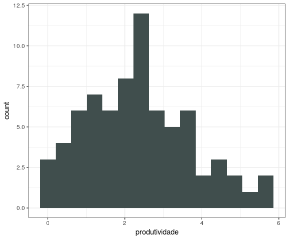

```r
cacc %>%
  ggplot(aes(x = produtividade)) +
  geom_histogram(bins = 15, fill = paleta[1])
```

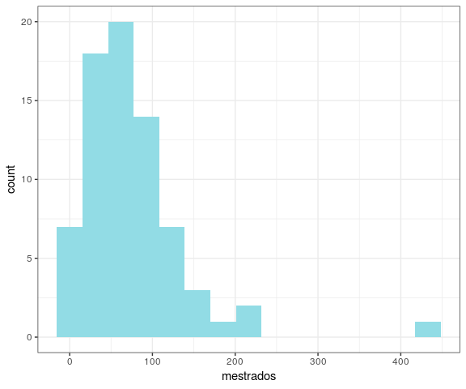

```r
cacc %>%
  ggplot(aes(x = mestrados)) +
  geom_histogram(bins = 15, fill = paleta[2])
```

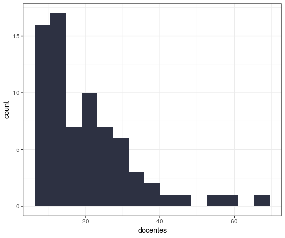

```r
cacc %>%
  ggplot(aes(x = docentes)) +
  geom_histogram(bins = 15, fill = paleta[4])
```

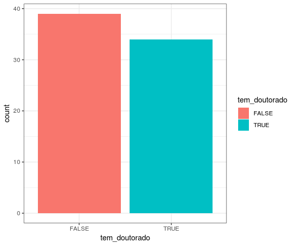

```r
cacc %>%
  ggplot(aes(x = tem_doutorado,  fill = tem_doutorado)) +
  geom_histogram(bins = 15, stat = "count")
```

Criando o modelo:

```r
modelo_mult = lm(produtividade ~ mestrados + docentes + tem_doutorado,
             data = cacc)

tidy(modelo_mult, conf.int = TRUE, conf.level = 0.95) %>% select(-statistic, -p.value, - std.error)
```

| term | estimate | conf.low | conf.high |
| --- | --- | --- | --- |
| (Intercept) | 1.0826767 | 0.6136079 | 1.5517454 |
| mestrados | 0.0001215 | -0.0061623 | 0.0064054 |
| docentes | 0.0314233 | -0.0037478 | 0.0665943 |
| tem_doutoradoTRUE | 1.3403224 | 0.7702601 | 1.9103848 |

```r
glance(modelo_mult) %>% select(r.squared)
```

| r.squared |
| --- |
| 0.47701 |

**i) Analisando o modelo gerado**

Regressão múltipla foi utilizada para analisar se o número de mestrandos, docentes e o fato de ter doutorado ou não no programa têm uma associação significativa com a produtividade. Os resultados da regressão indicam que um modelo com os 3 preditores no formato produtividade = mestrandos.0,0001 + docentes.0,03 + tem_doutorado.1,34 + 1.08 explicam 47,70% da variância da variável de resposta (R2 = 0,47701). Mestrandos, medida em número de alunos de mestrado, não tem uma relação significativa com o erro (b = [-0,006; 0,006], IC com 95%), assim como docentes, medida em número de professores permanentes (b = [-0,003; 0,06], IC com 95%). O fato de ter doutorado no programa (0 se não tem e 1 se tem), entretanto, tem uma relação significativa com o erro (b = [0,77; 1,91], IC com 95%).

O aumento de 1 unidade em mestrandos produz um aumento de 0,0001 na produtividade, enquanto um aumento de 1 unidade em docentes produz um aumento de 0,03 na produtividade. O fato de o programa ter doutorado, por sua vez, aumenta em 1,34 a produtividade.

**ii) Implicações**

O número de mestrandos, professores e o fato de o programa possuir doutorado ou não explicam 47% da variação da variável produtividade usando um modelo linear. Esse coeficiente é considerado baixo, nos levando a acreditar que talvez existam outros fatores que não estão nos dados que impactem nessa produtividade ou então que tais variáveis independentes possam explicar a variação da produtividade através de um modelo não linear.

Pelo modelo gerado, o número de mestrandos e professores praticamente não impacta na produtividade, mas o fato de o curso possuir doutorado aumenta a produtividade em 1,34 unidade, que é um valor considerável tendo em vista que os valores de produtividade observados na amostra variam de 0 a 5,66.